# Project: Exploratory Data Analysis on Lahman's Database

### Research Question 2: Do maximum salary players get paid more based on HR's or Batting avg?

##### This question requires that I familarize myself with the following datafiles:

- BattingDF
- SalariesDF

```python
print("Dimensions of BattingDF:" + str(BattingDF.shape))
BattingDF.head(1)
```

```
Dimensions of BattingDF:(102816, 22)
```

|  | playerID | yearID | stint | teamID | lgID | G | AB | R | H | 2B | ... | RBI | SB | CS | BB | SO | IBB | HBP | SH | SF | GIDP |
| --- | --- | --- | --- | --- | --- | --- | --- | --- | --- | --- | --- | --- | --- | --- | --- | --- | --- | --- | --- | --- | --- |
| 0 | abercda01 | 1871 | 1 | TRO | NaN | 1 | 4 | 0 | 0 | 0 | ... | 0.0 | 0.0 | 0.0 | 0 | 0.0 | NaN | NaN | NaN | NaN | NaN |

1 rows × 22 columns

```python
print("Dimensions of SalariesDF:" + str(SalariesDF.shape))
SalariesDF.head(1)
```

```
Dimensions of SalariesDF:(26428, 5)
```

|  | yearID | teamID | lgID | playerID | salary |
| --- | --- | --- | --- | --- | --- |
| 0 | 1985 | ATL | NL | barkele01 | 870000 |

I notice here that the dataframe containing the salary information starts at 1985 while the dataframe containing the batting information starts all the way back in 1871. I'll double check min value for the year in the cell below.

```python
batting_df_min_year = BattingDF['yearID'].min()
salaries_df_min_year = SalariesDF['yearID'].min()
print("The batting Dataframe dates all the way back to {}".format(batting_df_min_year))
print("The salary Dataframe dates all the way back to {}".format(salaries_df_min_year))
"""This is more than 100 years apart!"""
```

```
The batting Dataframe dates all the way back to 1871
The salary Dataframe dates all the way back to 1985
```

```
'This is more than 100 years apart!'
```

We can continue our analysis regardless of the difference in years between the two dataframes. However, I will cut the batting dataframe to only include years since 1985.

```python
Batting1985 = BattingDF[BattingDF['yearID'] >= 1985]
#This code only includes years from 1985 and on.
Batting1985['yearID'].min()#check
```

```
1985
```

```python
Batting1985.head(1)
#I can see here it eliminates over 60,000 rows.
```

|  | playerID | yearID | stint | teamID | lgID | G | AB | R | H | 2B | ... | RBI | SB | CS | BB | SO | IBB | HBP | SH | SF | GIDP |
| --- | --- | --- | --- | --- | --- | --- | --- | --- | --- | --- | --- | --- | --- | --- | --- | --- | --- | --- | --- | --- | --- |
| 62239 | aasedo01 | 1985 | 1 | BAL | AL | 54 | 0 | 0 | 0 | 0 | ... | 0.0 | 0.0 | 0.0 | 0 | 0.0 | 0.0 | 0.0 | 0.0 | 0.0 | 0.0 |

1 rows × 22 columns

I am curious how the distribution of player salaries look like. I noticed there are five columns of data. I want to see what the data types are and if there are any potential problems in this dataset that would cause problems down the line.

```python
print(SalariesDF.dtypes)
"""yearID and salary contain interger values"""
```

```
yearID       int64
teamID      object
lgID        object
playerID    object
salary       int64
dtype: object
```

```
'yearID and salary contain interger values'
```

```python
SalariesDF.isnull().sum()#no null values
```

```
yearID      0
teamID      0
lgID        0
playerID    0
salary      0
dtype: int64
```

```python
SalariesDF.describe()
```

|  | yearID | salary |
| --- | --- | --- |
| count | 26428.000000 | 2.642800e+04 |
| mean | 2000.878727 | 2.085634e+06 |
| std | 8.909314 | 3.455348e+06 |
| min | 1985.000000 | 0.000000e+00 |
| 25% | 1994.000000 | 2.947020e+05 |
| 50% | 2001.000000 | 5.500000e+05 |
| 75% | 2009.000000 | 2.350000e+06 |
| max | 2016.000000 | 3.300000e+07 |

I can see there are 26,428 rows of data containing various player salaries and teams. The above function only provides statistics on the numerical data types. The mean salary is about 2.086 million. The median value is significantly lower at around 550,000. From this salary summary, I can deduce that a large portion of players get paid below 550,000. I'll produce some visualizations to support this fact down below.

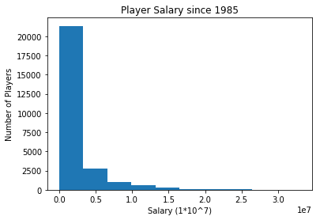

```python
%pylab inline
plt.hist(SalariesDF['salary'])
plt.xlabel('Salary (1*10^7)')
plt.ylabel('Number of Players')
plt.title('Player Salary since 1985')
plt.show()
```

I can see here that a large chunk of players fall below the 550,000 salary range. This histogram shows a positive (right) skew and is a visual representation of the descriptive statistics shown above. The histogram is very dense around the lower values. I am curious how the mean salary value varies over time.

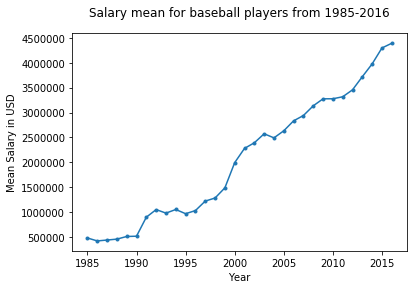

```python
%pylab inline
salary_mean = SalariesDF.groupby(['yearID'])['salary'].mean()
plt.plot(salary_mean,marker='.')
plt.title('Salary mean for baseball players from 1985-2016' ).set_position([.5, 1.05])
plt.xlabel('Year')
plt.ylabel('Mean Salary in USD')
plt.show()
```

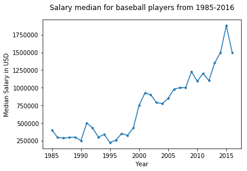

```python
%pylab inline
salary_median = SalariesDF.groupby(['yearID'])['salary'].median()
plt.plot(salary_median,marker='.')
plt.title('Salary median for baseball players from 1985-2016' ).set_position([.5, 1.05])
plt.xlabel('Year')
plt.ylabel('Median Salary in USD')
plt.show()
```

The above two graphs show a visual representation of the mean and the median value of player salaries from the years 1985-2016. These graphs tell different stories for the sample population. In this case, the mean value graph is more inclusive of the outliers (higher salary players) in the sample whereas the graph of the median is better at including the lesser-paid athletes. Both graphs show an increasing salary over time. We can largely attribute this to salary inflation. (Many other factors are the cause but will be beyond the scope of this analysis)

I am curious as to who the highest paid athletes are. I want to return the players commanding the highest salary since 1985.

```python
max_salary = SalariesDF.groupby('yearID').salary.max()
#returns a series with max salary in each year
max_salary = max_salary.to_frame()#turn this into a dataframe
max_salary.reset_index(inplace=True)#reset index
max_salary.head()
```

|  | yearID | salary |
| --- | --- | --- |
| 0 | 1985 | 2130300 |
| 1 | 1986 | 2800000 |
| 2 | 1987 | 2127333 |
| 3 | 1988 | 2340000 |
| 4 | 1989 | 2766667 |

I now have the values for the max salary associated with each year starting from 1985 leading up to 2016. My next step is to get the playerID's associated with these salaries. I will merge the trimmed dataframe with the original dataframe to obtain the playerID's associated with the salary number.

```python
max_salary.shape #32 rows of data
```

```
(32, 2)
```

```python
Max_salary = max_salary.merge(SalariesDF,on=['yearID','salary'],how='inner')
Max_salary.head(1)#it works!
```

|  | yearID | salary | teamID | lgID | playerID |
| --- | --- | --- | --- | --- | --- |
| 0 | 1985 | 2130300 | PHI | NL | schmimi01 |

```python
max_salary_count = Max_salary.groupby('playerID').count()
max_salary_count #some playerID's are associated with multiple years.
```

| playerID | yearID | salary | teamID | lgID |
| --- | --- | --- | --- | --- |
| belleal01 | 2 | 2 | 2 | 2 |
| bonilbo01 | 3 | 3 | 3 | 3 |
| brownke01 | 1 | 1 | 1 | 1 |
| fieldce01 | 2 | 2 | 2 | 2 |
| fostege01 | 1 | 1 | 1 | 1 |
| giambja01 | 1 | 1 | 1 | 1 |
| greinza01 | 1 | 1 | 1 | 1 |
| hershor01 | 1 | 1 | 1 | 1 |
| kershcl01 | 2 | 2 | 2 | 2 |
| ramirma02 | 1 | 1 | 1 | 1 |
| rodrial01 | 11 | 11 | 11 | 11 |
| schmimi01 | 2 | 2 | 2 | 2 |
| sheffga01 | 1 | 1 | 1 | 1 |
| smithoz01 | 1 | 1 | 1 | 1 |
| strawda01 | 1 | 1 | 1 | 1 |
| yountro01 | 1 | 1 | 1 | 1 |

Alex Rodriguez was the highest paid player 11 times!

```python
max_salary_count.shape
#16 different players accounting for the 32 years of data
```

```
(16, 4)
```

This shows there aren't 32 different players for each year. Some players just command the top salary through multiple years. This isn't uncommon.

Next I want the batting statistics associated with these players... To do so i'll merge the above dataframe with the batting dataframe on the playerID and yearID column variables. This ensures the correct player and the appropriate year are merged into one dataframe.

```python
Player_stats_and_salaries = Max_salary.merge(Batting1985,on=['playerID','yearID'],
                                             how='inner')
#merge the two dataframes on yearID and playerID

Player_stats_and_salaries.drop(['lgID_x','lgID_y','stint','2B','3B','SB','CS','BB','SO','IBB','HBP'
                                ,'SH','SF','GIDP'],axis=1,
                              inplace=True)
#drop irrelevant columns for this analysis
```

```python
Player_stats_and_salaries.shape
```

```
(35, 11)
```

I notice there are 35 rows of data instead of 32. I am curious as to why that is.

```python
player_stats_and_salaries_count = Player_stats_and_salaries.groupby('playerID').count()
player_stats_and_salaries_count.shape
```

```
(16, 10)
```

There are still 16 rows of data, so it's probably not an duplicate error. My guess is that some players played on different teams within the same year. This would explain the extra rows of data. To check this, I'll just check for the unique values of years.

```python
Player_stats_and_salaries['yearID'].value_counts()
```

```
1986    2
1996    2
1998    2
2016    1
2015    1
1987    1
1988    1
1989    1
1990    1
1991    1
1992    1
1993    1
1994    1
1995    1
1997    1
```

[output cut: 18 more lines]

Here I see a few rows (3 to be exact) where there are multiple entries for the same row. I guessed right! To fix this problem, I will need to sum up the statistics for the players within the same years regardless of what team they are on. I can't just drop duplicates because this will remove valuable information about the player I will need for this analysis.

```python
Max_salary_player_yearly = Player_stats_and_salaries.groupby(['playerID',
                                                              'yearID']).sum()
#Groupby playerID and yearID and sum the batting statistics.
#Then create the batting average column here:
Max_salary_player_yearly['BA'] = Max_salary_player_yearly['H']/Max_salary_player_yearly['AB']
#check if it has been added
Max_salary_player_yearly.shape
#back to 32 rows!
```

```
(32, 8)
```

If I had created the Batting Average before the merge, the sum() method would have been applied on batting average and would have created a very high number. This new dataframe also has the players sorted with their respective years. Now I want to examine the Home Run and Batting Average statistics for these players more in-depth.

```python
Max_salary_player_yearly['HR'].describe()
```

```
count    32.000000
mean     24.843750
std      16.445628
min       0.000000
25%      14.000000
50%      29.000000
75%      35.000000
max      57.000000
Name: HR, dtype: float64
```

```python
Max_salary_player_yearly['BA'].describe()
```

```
count    32.000000
mean      0.257155
std       0.054852
min       0.075758
25%       0.243421
50%       0.271127
75%       0.294008
max       0.320661
Name: BA, dtype: float64
```

The mean Batting Average for these 16 players is 0.2572. This value is close to the median value, so the distribution is close to symmetrical with a max value at 0.3207 and minimum at 0.0758.As noted earlier, I am curious as to why some players produced 0 Home runs and other low statistics. I want to check the smaller values from this dataframe and investigate if there was an injury orsome other reason behind the poor stats.

```python
hr_count = Max_salary_player_yearly['HR'].value_counts()
hr_count.sort_index(axis=0,inplace=True)
hr_count
#returns a pandas series with sum of homeruns and counts within this DF.
```

```
0     4
1     1
3     1
7     1
14    2
16    1
17    1
18    1
19    1
20    1
22    1
28    1
30    3
31    1
33    1
34    1
35    3
37    1
39    1
43    1
47    1
48    1
52    1
57    1
Name: HR, dtype: int64
```

```
'A large proportion of this dataframe has 0 values, I need to investigate'
```

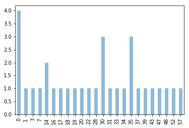

```python
hr_count.plot(kind='bar',alpha=0.5)
"""A large proportion of this dataframe has 0 values, I need to investigate"""
```

I'll start by investigating all values below 10

```python
for i,j in hr_count.iteritems():
    if i < 10:
        print("Home Runs:" + str(i))
        print("Count:" + str(j))
    else:
        break
```

```
Home Runs:0
Count:4
Home Runs:1
Count:1
Home Runs:3
Count:1
Home Runs:7
Count:1
```

I choose to investigate these points.

```python
print (Max_salary_player_yearly[Max_salary_player_yearly['HR'] < 10])
```

```
                    salary    G   AB   R    H  HR   RBI        BA
playerID  yearID
brownke01 2000    15714286   33   66   2    5   0   3.0  0.075758
greinza01 2014    26000000   32   60   5   12   1   3.0  0.200000
hershor01 1989     2766667   35   77   4   14   0   2.0  0.181818
kershcl01 2015    32571000   34   71   2    9   0   2.0  0.126761
          2016    33000000   23   46   2    8   0   3.0  0.173913
rodrial01 2013    29000000   44  156  21   38   7  19.0  0.243590
smithoz01 1988     2340000  153  575  80  155   3  51.0  0.269565
```

After doing a little outside research, I find that the playerID's corresponding to brownke01, herschor01, kerschl01, and greinza01 are all pitchers which would explain why these 4 players have poor batting stats. Pitchers in the MLB generally have poor offensive statistics. Since my analysis is focused on the offensive side, I decide that I want to remove these players from my dataframe since they aren't being for offense. The playerID's correlating to smithoz01 and rodrial01 belong to ozzie smith and alex rodriguez, who play the shortstop position. (outside investigation) We can safely attribute their high salaries to their offensive production because shortstops rarely get paid for their defense. Next step is locating these playerID's. Before doing that, I'll copy the data into a new variable first

```python
top_offensive_salaries = Player_stats_and_salaries.copy()
#create a copy
```

```python
top_offensive_salaries.loc[top_offensive_salaries['playerID'] == 'hershor01']
#index 5 corresponds to this playerID
```

|  | yearID | salary | teamID_x | playerID | teamID_y | G | AB | R | H | HR | RBI |
| --- | --- | --- | --- | --- | --- | --- | --- | --- | --- | --- | --- |
| 5 | 1989 | 2766667 | LAN | hershor01 | LAN | 35 | 77 | 4 | 14 | 0 | 2.0 |

```python
top_offensive_salaries.drop(top_offensive_salaries.index[5]
                               ,inplace=True,axis=0)
top_offensive_salaries.reset_index(drop=True,inplace=True)
#remove the corresponding row and reinitialize the index
```

```python
top_offensive_salaries.loc[top_offensive_salaries['playerID']
                              == 'brownke01']
#Index 17 corresponds to playerID = 'brownke01'
```

|  | yearID | salary | teamID_x | playerID | teamID_y | G | AB | R | H | HR | RBI |
| --- | --- | --- | --- | --- | --- | --- | --- | --- | --- | --- | --- |
| 17 | 2000 | 15714286 | LAN | brownke01 | LAN | 33 | 66 | 2 | 5 | 0 | 3.0 |

```python
top_offensive_salaries.drop(
    top_offensive_salaries.index[17],inplace=True,axis=0)
top_offensive_salaries.reset_index(drop=True,inplace=True)
#drop the index corresponding to 'brownke01'
```

```python
top_offensive_salaries.loc[top_offensive_salaries['playerID']
                              == 'greinza01']
#Index 30 = 'greinza01'
```

|  | yearID | salary | teamID_x | playerID | teamID_y | G | AB | R | H | HR | RBI |
| --- | --- | --- | --- | --- | --- | --- | --- | --- | --- | --- | --- |
| 30 | 2014 | 26000000 | LAN | greinza01 | LAN | 32 | 60 | 5 | 12 | 1 | 3.0 |

```python
top_offensive_salaries.drop(top_offensive_salaries.index[30],inplace=True,axis=0)
top_offensive_salaries.reset_index(drop=True,inplace=True)
#drop index row 30 and reset index
```

```python
top_offensive_salaries.loc[top_offensive_salaries['playerID']
                              == 'kershcl01']
```

|  | yearID | salary | teamID_x | playerID | teamID_y | G | AB | R | H | HR | RBI |
| --- | --- | --- | --- | --- | --- | --- | --- | --- | --- | --- | --- |
| 30 | 2015 | 32571000 | LAN | kershcl01 | LAN | 34 | 71 | 2 | 9 | 0 | 2.0 |
| 31 | 2016 | 33000000 | LAD | kershcl01 | LAN | 23 | 46 | 2 | 8 | 0 | 3.0 |

```python
top_offensive_salaries.drop(top_offensive_salaries.index[30:32],
                               inplace=True,axis=0)
top_offensive_salaries.reset_index(drop=True,inplace=True)
top_offensive_salaries.shape
#5 rows of data have been removed from this dataframe.
#Lets check if there are still 16 different players
```

```
(30, 11)
```

```python
Max_batters = top_offensive_salaries.groupby(['playerID','yearID']).sum()
Max_batters['BA'] = Max_batters['H']/Max_batters['AB']
#Group the trimmed dataframe and create the batting average column again
```

```python
Max_HR = Max_batters['HR']
Max_salary = Max_batters['salary']

print('Correlation between HR and salaries for max players')
print(correlation(Max_HR,Max_salary))
```

```
Correlation between HR and salaries for max players
0.15649957099001505
```

```python
Max_BA = Max_batters['BA']

print('Correlation between Batting Avg and salaries for max players')
print(correlation(Max_BA,Max_salary))
```

```
Correlation between Batting Avg and salaries for max players
0.32402466262151514
```

Relationship between batting average and salary seems to be stronger than the relationship between home runs and salary. I'd like to run this test with a bigger sample size

```python
print (Max_batters['HR'].describe())
print(' ')
print (Max_salary_player_yearly['HR'].describe())
```

```
count    27.000000
mean     29.407407
std      13.565395
min       3.000000
25%      18.500000
50%      30.000000
75%      36.000000
max      57.000000
Name: HR, dtype: float64

count    32.000000
mean     24.843750
std      16.445628
min       0.000000
25%      14.000000
50%      29.000000
75%      35.000000
max      57.000000
Name: HR, dtype: float64
```

After removing the four pitchers, I notice that the count goes down from 32 to 27. The mean HR average has also increased to ~29.5 and a lot closer to the median value of 30. Standard deviation value for HR's has also decreased meaning this distribution is a lot less spread out.

```python
print (Max_batters['BA'].describe())
print(' ')
print (Max_salary_player_yearly['BA'].describe())
```

```
count    27.000000
mean      0.276693
std       0.025709
min       0.225352
25%       0.258528
50%       0.276139
75%       0.297455
max       0.320661
Name: BA, dtype: float64

count    32.000000
mean      0.257155
std       0.054852
min       0.075758
25%       0.243421
50%       0.271127
75%       0.294008
max       0.320661
Name: BA, dtype: float64
```

```python
Max_batters.loc[Max_batters['HR'].idxmax()]
#Alex Rodriguez in 2002 had the max HR for this Dataframe.
```

```
salary    2.200000e+07
G         1.620000e+02
AB        6.240000e+02
R         1.250000e+02
H         1.870000e+02
HR        5.700000e+01
RBI       1.420000e+02
BA        2.996795e-01
Name: (rodrial01, 2002), dtype: float64
```

```python
Max_batters.loc[Max_batters['BA'].idxmax()]
#Alex Rodriguez in 2005 had the max Batting Average for this DF.
```

```
salary    2.600000e+07
G         1.620000e+02
AB        6.050000e+02
R         1.240000e+02
H         1.940000e+02
HR        4.800000e+01
RBI       1.300000e+02
BA        3.206612e-01
Name: (rodrial01, 2005), dtype: float64
```

I'd like to analyze the relationship between Home Runs and salary in 2002 and Batting average with salary in 2005. I'll create these dataframes first. The following part will involve these following dataframes -BattingDF -FieldingDF -SalariesDF

```python
Batting2002 = BattingDF.copy()[BattingDF.yearID == 2002]#batting stats for 2002
Batting2005 = BattingDF.copy()[BattingDF.yearID == 2005]#batting stats for 2005
#I prefer to keep them separate
```

```python
Fielding2002 = FieldingDF[FieldingDF['yearID']==2002]
Fielding2005 = FieldingDF[FieldingDF['yearID']==2005]
"""I want to trim the salary and field dataframes
down a bit so I don't need to clean data as much later"""
Salaries2002 = SalariesDF[SalariesDF['yearID']==2002]
Salaries2005 = SalariesDF[SalariesDF['yearID']==2005]
```

I want to find correlation between certain batting statistics (batting average, home runs) and salary.

```python
Batting2002.dtypes
```

```
playerID     object
yearID        int64
stint         int64
teamID       object
lgID         object
G             int64
AB            int64
R             int64
H             int64
2B            int64
3B            int64
HR            int64
RBI         float64
SB          float64
CS          float64
BB            int64
SO          float64
IBB         float64
HBP         float64
SH          float64
SF          float64
GIDP        float64
dtype: object
```

```python
Batting2005.dtypes# check data types
```

```
playerID     object
yearID        int64
stint         int64
teamID       object
lgID         object
G             int64
AB            int64
R             int64
H             int64
2B            int64
3B            int64
HR            int64
RBI         float64
SB          float64
CS          float64
BB            int64
SO          float64
IBB         float64
HBP         float64
SH          float64
SF          float64
GIDP        float64
dtype: object
```

```python
print(Batting2002.shape)
print(Batting2005.shape)#dimensions of these dataframes
```

```
(1319, 22)
(1330, 22)
```

```python
print(Batting2002.playerID.unique().shape)
print(Batting2005.playerID.unique().shape)#unique playerID's,
```

```
(1218,)
(1237,)
```

That's odd, the number of unique playerID's dont match the rows in the Batting2002 and Batting2005 Dataframe.

```python
print(Batting2002.duplicated().sum())
print(Batting2005.duplicated().sum())#prints sum of duplicate rows
```

```
0
0
```

They aren't duplicate rows... I'll focus on the 2002 dataframe first.

```python
Batting2002[Batting2002.duplicated(['playerID'],keep=False)]
#code prints out duplicate rows based on playerID values
```

|  | playerID | yearID | stint | teamID | lgID | G | AB | R | H | 2B | ... | RBI | SB | CS | BB | SO | IBB | HBP | SH | SF | GIDP |
| --- | --- | --- | --- | --- | --- | --- | --- | --- | --- | --- | --- | --- | --- | --- | --- | --- | --- | --- | --- | --- | --- |
| 81980 | agbaybe01 | 2002 | 1 | COL | NL | 48 | 117 | 10 | 24 | 5 | ... | 19.0 | 1.0 | 0.0 | 10 | 35.0 | 0.0 | 0.0 | 0.0 | 1.0 | 4.0 |
| 81981 | agbaybe01 | 2002 | 2 | BOS | AL | 13 | 37 | 5 | 11 | 1 | ... | 8.0 | 0.0 | 0.0 | 6 | 5.0 | 1.0 | 0.0 | 0.0 | 0.0 | 1.0 |
| 81992 | alomasa02 | 2002 | 1 | CHA | AL | 51 | 167 | 21 | 48 | 10 | ... | 25.0 | 0.0 | 0.0 | 5 | 14.0 | 0.0 | 1.0 | 1.0 | 2.0 | 5.0 |
| 81993 | alomasa02 | 2002 | 2 | COL | NL | 38 | 116 | 8 | 31 | 4 | ... | 12.0 | 0.0 | 0.0 | 4 | 19.0 | 0.0 | 0.0 | 0.0 | 0.0 | 6.0 |
| 82068 | beverja01 | 2002 | 1 | CLE | AL | 4 | 0 | 0 | 0 | 0 | ... | 0.0 | 0.0 | 0.0 | 0 | 0.0 | 0.0 | 0.0 | 0.0 | 0.0 | 0.0 |
| 82069 | beverja01 | 2002 | 2 | DET | AL | 3 | 0 | 0 | 0 | 0 | ... | 0.0 | 0.0 | 0.0 | 0 | 0.0 | 0.0 | 0.0 | 0.0 | 0.0 | 0.0 |
| 82078 | bocachi01 | 2002 | 1 | LAN | NL | 49 | 65 | 12 | 14 | 3 | ... | 9.0 | 1.0 | 1.0 | 5 | 19.0 | 0.0 | 0.0 | 0.0 | 0.0 | 1.0 |
| 82079 | bocachi01 | 2002 | 2 | DET | AL | 34 | 103 | 14 | 23 | 4 | ... | 8.0 | 2.0 | 2.0 | 5 | 22.0 | 0.0 | 0.0 | 1.0 | 0.0 | 2.0 |
| 82085 | borbope02 | 2002 | 1 | TOR | AL | 16 | 0 | 0 | 0 | 0 | ... | 0.0 | 0.0 | 0.0 | 0 | 0.0 | 0.0 | 0.0 | 0.0 | 0.0 | 0.0 |
| 82086 | borbope02 | 2002 | 2 | HOU | NL | 56 | 3 | 0 | 0 | 0 | ... | 0.0 | 0.0 | 0.0 | 0 | 3.0 | 0.0 | 0.0 | 0.0 | 0.0 | 0.0 |
| 82099 | branyru01 | 2002 | 1 | CLE | AL | 50 | 161 | 16 | 33 | 4 | ... | 17.0 | 1.0 | 2.0 | 17 | 65.0 | 0.0 | 0.0 | 0.0 | 2.0 | 3.0 |
| 82100 | branyru01 | 2002 | 2 | CIN | NL | 84 | 217 | 34 | 53 | 9 | ... | 39.0 | 3.0 | 1.0 | 34 | 86.0 | 3.0 | 2.0 | 0.0 | 2.0 | 2.0 |
| 82106 | broweji01 | 2002 | 1 | CIN | NL | 22 | 4 | 0 | 0 | 0 | ... | 0.0 | 0.0 | 0.0 | 0 | 1.0 | 0.0 | 0.0 | 1.0 | 0.0 | 0.0 |
| 82107 | broweji01 | 2002 | 2 | MON | NL | 30 | 5 | 0 | 0 | 0 | ... | 0.0 | 0.0 | 0.0 | 0 | 2.0 | 0.0 | 0.0 | 0.0 | 0.0 | 0.0 |
| 82113 | buchabr01 | 2002 | 1 | MIN | AL | 44 | 135 | 19 | 34 | 5 | ... | 15.0 | 2.0 | 1.0 | 6 | 33.0 | 0.0 | 2.0 | 0.0 | 0.0 | 4.0 |
| 82114 | buchabr01 | 2002 | 2 | SDN | NL | 48 | 92 | 12 | 27 | 5 | ... | 13.0 | 0.0 | 1.0 | 9 | 26.0 | 0.0 | 1.0 | 0.0 | 0.0 | 2.0 |
| 82118 | burbada01 | 2002 | 1 | TEX | AL | 23 | 5 | 0 | 1 | 0 | ... | 0.0 | 0.0 | 0.0 | 0 | 3.0 | 0.0 | 0.0 | 0.0 | 0.0 | 0.0 |
| 82119 | burbada01 | 2002 | 2 | CLE | AL | 12 | 0 | 0 | 0 | 0 | ... | 0.0 | 0.0 | 0.0 | 0 | 0.0 | 0.0 | 0.0 | 0.0 | 0.0 | 0.0 |
| 82126 | bushho01 | 2002 | 1 | TOR | AL | 23 | 78 | 9 | 18 | 2 | ... | 2.0 | 2.0 | 0.0 | 2 | 12.0 | 0.0 | 2.0 | 1.0 | 0.0 | 2.0 |
| 82127 | bushho01 | 2002 | 2 | FLO | NL | 40 | 54 | 7 | 12 | 0 | ... | 5.0 | 2.0 | 1.0 | 3 | 13.0 | 0.0 | 0.0 | 1.0 | 0.0 | 0.0 |
| 82134 | cabrejo02 | 2002 | 1 | CLE | AL | 38 | 72 | 5 | 8 | 1 | ... | 7.0 | 1.0 | 1.0 | 5 | 13.0 | 0.0 | 1.0 | 0.0 | 1.0 | 3.0 |
| 82135 | cabrejo02 | 2002 | 2 | LAN | NL | 10 | 12 | 3 | 4 | 1 | ... | 1.0 | 0.0 | 0.0 | 2 | 2.0 | 0.0 | 0.0 | 1.0 | 0.0 | 0.0 |
| 82147 | casanra01 | 2002 | 1 | MIL | NL | 31 | 87 | 3 | 16 | 1 | ... | 8.0 | 0.0 | 0.0 | 10 | 18.0 | 4.0 | 1.0 | 0.0 | 1.0 | 3.0 |
| 82148 | casanra01 | 2002 | 2 | BAL | AL | 2 | 1 | 0 | 0 | 0 | ... | 0.0 | 0.0 | 0.0 | 0 | 1.0 | 0.0 | 0.0 | 0.0 | 0.0 | 0.0 |
| 82166 | chenbr01 | 2002 | 1 | NYN | NL | 1 | 0 | 0 | 0 | 0 | ... | 0.0 | 0.0 | 0.0 | 0 | 0.0 | 0.0 | 0.0 | 0.0 | 0.0 | 0.0 |
| 82167 | chenbr01 | 2002 | 2 | MON | NL | 15 | 12 | 3 | 5 | 1 | ... | 1.0 | 0.0 | 0.0 | 0 | 3.0 | 0.0 | 0.0 | 1.0 | 0.0 | 0.0 |
| 82168 | chenbr01 | 2002 | 3 | CIN | NL | 39 | 3 | 0 | 0 | 0 | ... | 0.0 | 0.0 | 0.0 | 0 | 1.0 | 0.0 | 0.0 | 1.0 | 0.0 | 0.0 |
| 82179 | clarkbr02 | 2002 | 1 | CIN | NL | 51 | 66 | 6 | 10 | 3 | ... | 9.0 | 1.0 | 2.0 | 6 | 9.0 | 2.0 | 1.0 | 1.0 | 0.0 | 2.0 |
| 82180 | clarkbr02 | 2002 | 2 | NYN | NL | 10 | 12 | 3 | 5 | 1 | ... | 1.0 | 0.0 | 0.0 | 1 | 2.0 | 0.0 | 0.0 | 0.0 | 0.0 | 0.0 |
| 82192 | colonba01 | 2002 | 1 | CLE | AL | 16 | 6 | 0 | 1 | 0 | ... | 0.0 | 0.0 | 0.0 | 0 | 3.0 | 0.0 | 0.0 | 0.0 | 0.0 | 0.0 |
| ... | ... | ... | ... | ... | ... | ... | ... | ... | ... | ... | ... | ... | ... | ... | ... | ... | ... | ... | ... | ... | ... |
| 83009 | rolensc01 | 2002 | 1 | PHI | NL | 100 | 375 | 52 | 97 | 21 | ... | 66.0 | 5.0 | 2.0 | 52 | 68.0 | 2.0 | 8.0 | 0.0 | 3.0 | 12.0 |
| 83010 | rolensc01 | 2002 | 2 | SLN | NL | 55 | 205 | 37 | 57 | 8 | ... | 44.0 | 3.0 | 2.0 | 20 | 34.0 | 2.0 | 4.0 | 0.0 | 0.0 | 10.0 |
| 83013 | romanja01 | 2002 | 1 | TEX | AL | 29 | 54 | 8 | 11 | 4 | ... | 4.0 | 2.0 | 0.0 | 4 | 13.0 | 0.0 | 0.0 | 1.0 | 1.0 | 0.0 |
| 83014 | romanja01 | 2002 | 2 | COL | NL | 18 | 37 | 9 | 12 | 0 | ... | 1.0 | 4.0 | 1.0 | 3 | 11.0 | 0.0 | 0.0 | 1.0 | 0.0 | 0.0 |
| 83029 | sadledo01 | 2002 | 1 | KCA | AL | 35 | 68 | 10 | 13 | 1 | ... | 5.0 | 3.0 | 1.0 | 4 | 12.0 | 0.0 | 0.0 | 0.0 | 1.0 | 0.0 |
| 83030 | sadledo01 | 2002 | 2 | TEX | AL | 38 | 30 | 6 | 3 | 1 | ... | 2.0 | 2.0 | 2.0 | 3 | 7.0 | 0.0 | 2.0 | 1.0 | 0.0 | 1.0 |
| 83035 | sanchdu01 | 2002 | 1 | ARI | NL | 6 | 0 | 0 | 0 | 0 | ... | 0.0 | 0.0 | 0.0 | 0 | 0.0 | 0.0 | 0.0 | 0.0 | 0.0 | 0.0 |
| 83036 | sanchdu01 | 2002 | 2 | PIT | NL | 3 | 0 | 0 | 0 | 0 | ... | 0.0 | 0.0 | 0.0 | 0 | 0.0 | 0.0 | 0.0 | 0.0 | 0.0 | 0.0 |
| 83070 | shueypa01 | 2002 | 1 | CLE | AL | 39 | 0 | 0 | 0 | 0 | ... | 0.0 | 0.0 | 0.0 | 0 | 0.0 | 0.0 | 0.0 | 0.0 | 0.0 | 0.0 |
| 83071 | shueypa01 | 2002 | 2 | LAN | NL | 28 | 3 | 0 | 1 | 0 | ... | 0.0 | 0.0 | 0.0 | 0 | 2.0 | 0.0 | 0.0 | 0.0 | 0.0 | 0.0 |
| 83112 | stevele01 | 2002 | 1 | MON | NL | 63 | 205 | 28 | 39 | 6 | ... | 31.0 | 1.0 | 0.0 | 39 | 57.0 | 5.0 | 0.0 | 0.0 | 1.0 | 4.0 |
| 83113 | stevele01 | 2002 | 2 | CLE | AL | 53 | 153 | 22 | 34 | 7 | ... | 26.0 | 0.0 | 0.0 | 15 | 32.0 | 0.0 | 0.0 | 0.0 | 4.0 | 5.0 |
| 83120 | stricsc01 | 2002 | 1 | MON | NL | 1 | 0 | 0 | 0 | 0 | ... | 0.0 | 0.0 | 0.0 | 0 | 0.0 | 0.0 | 0.0 | 0.0 | 0.0 | 0.0 |
| 83121 | stricsc01 | 2002 | 2 | NYN | NL | 68 | 0 | 0 | 0 | 0 | ... | 0.0 | 0.0 | 0.0 | 0 | 0.0 | 0.0 | 0.0 | 0.0 | 0.0 | 0.0 |
| 83153 | thomsjo01 | 2002 | 1 | COL | NL | 21 | 34 | 2 | 6 | 0 | ... | 2.0 | 0.0 | 0.0 | 2 | 12.0 | 0.0 | 0.0 | 3.0 | 1.0 | 0.0 |
| 83154 | thomsjo01 | 2002 | 2 | NYN | NL | 9 | 18 | 2 | 5 | 0 | ... | 1.0 | 0.0 | 0.0 | 1 | 7.0 | 0.0 | 0.0 | 3.0 | 0.0 | 0.0 |
| 83158 | timlimi01 | 2002 | 1 | SLN | NL | 42 | 6 | 0 | 0 | 0 | ... | 0.0 | 0.0 | 0.0 | 0 | 4.0 | 0.0 | 0.0 | 0.0 | 0.0 | 0.0 |
| 83159 | timlimi01 | 2002 | 2 | PHI | NL | 30 | 0 | 0 | 0 | 0 | ... | 0.0 | 0.0 | 0.0 | 0 | 0.0 | 0.0 | 0.0 | 0.0 | 0.0 | 0.0 |
| 83171 | trubych01 | 2002 | 1 | MON | NL | 35 | 105 | 12 | 27 | 5 | ... | 7.0 | 1.0 | 1.0 | 5 | 27.0 | 1.0 | 1.0 | 1.0 | 0.0 | 2.0 |
| 83172 | trubych01 | 2002 | 2 | DET | AL | 89 | 277 | 23 | 55 | 13 | ... | 15.0 | 1.0 | 1.0 | 5 | 71.0 | 0.0 | 2.0 | 3.0 | 5.0 | 5.0 |
| 83180 | valdeis01 | 2002 | 1 | TEX | AL | 23 | 3 | 0 | 0 | 0 | ... | 1.0 | 0.0 | 0.0 | 0 | 2.0 | 0.0 | 0.0 | 1.0 | 0.0 | 0.0 |
| 83181 | valdeis01 | 2002 | 2 | SEA | AL | 8 | 0 | 0 | 0 | 0 | ... | 0.0 | 0.0 | 0.0 | 0 | 0.0 | 0.0 | 0.0 | 0.0 | 0.0 | 0.0 |
| 83214 | walkepe01 | 2002 | 1 | NYN | NL | 1 | 0 | 0 | 0 | 0 | ... | 0.0 | 0.0 | 0.0 | 0 | 0.0 | 0.0 | 0.0 | 0.0 | 0.0 | 0.0 |
| 83215 | walkepe01 | 2002 | 2 | TOR | AL | 37 | 0 | 0 | 0 | 0 | ... | 0.0 | 0.0 | 0.0 | 0 | 0.0 | 0.0 | 0.0 | 0.0 | 0.0 | 0.0 |
| 83225 | weaveje01 | 2002 | 1 | DET | AL | 17 | 7 | 0 | 2 | 0 | ... | 1.0 | 0.0 | 0.0 | 0 | 4.0 | 0.0 | 0.0 | 0.0 | 0.0 | 0.0 |
| 83226 | weaveje01 | 2002 | 2 | NYA | AL | 15 | 0 | 0 | 0 | 0 | ... | 0.0 | 0.0 | 0.0 | 0 | 0.0 | 0.0 | 0.0 | 0.0 | 0.0 | 0.0 |
| 83236 | whiteri01 | 2002 | 1 | COL | NL | 41 | 0 | 0 | 0 | 0 | ... | 0.0 | 0.0 | 0.0 | 0 | 0.0 | 0.0 | 0.0 | 0.0 | 0.0 | 0.0 |
| 83237 | whiteri01 | 2002 | 2 | SLN | NL | 20 | 1 | 0 | 0 | 0 | ... | 0.0 | 0.0 | 0.0 | 0 | 1.0 | 0.0 | 0.0 | 0.0 | 0.0 | 0.0 |
| 83274 | wrighja01 | 2002 | 1 | MIL | NL | 19 | 33 | 0 | 5 | 3 | ... | 0.0 | 0.0 | 0.0 | 0 | 13.0 | 0.0 | 0.0 | 6.0 | 0.0 | 0.0 |
| 83275 | wrighja01 | 2002 | 2 | SLN | NL | 4 | 5 | 0 | 0 | 0 | ... | 0.0 | 0.0 | 0.0 | 0 | 3.0 | 0.0 | 0.0 | 1.0 | 0.0 | 0.0 |

199 rows × 22 columns

There are 199 rows associated with duplicate playerID's. This code also allows me to investigate the duplicates. I can see here that the players associated with the playerID's seem to have been on more than one team within the same season. The 'stint' column variable keeps track of the number of times they have switched teams. I am not concerned with the number of times the player switched teams for this analysis. Therefore, I will simply sum the batting statistics by the playerID's associated with the players. I want to check the playerID's with multiple stints first to see if the math adds up.

```python
Batting2002[Batting2002['stint'] > 1].shape
```

```
(101, 22)
```

101 rows for players with multiple stints. Of the original 1319 rows... 1319-101=1218 unique playerID's Math checks out fine, lets sum the values back up.

```python
Batting_stats_2002 = Batting2002.groupby(['playerID','yearID','teamID']).sum()
Batting_stats_2002.reset_index(inplace=True)#reset index
Batting_stats_2002.drop(['stint','GIDP','SF','SH','IBB','2B','3B','SB','CS','BB','SO','HBP'],axis=1,inplace=True)
print("Dimensions of this dataframe:" + str(Batting_stats_2002.shape))
Batting_stats_2002.head(1)
```

```
Dimensions of this dataframe:(1319, 9)
```

|  | playerID | yearID | teamID | G | AB | R | H | HR | RBI |
| --- | --- | --- | --- | --- | --- | --- | --- | --- | --- |
| 0 | abbotpa01 | 2002 | SEA | 7 | 0 | 0 | 0 | 0 | 0.0 |

```python
Batting2005[Batting2005.duplicated(['playerID'],keep=False)]
```

|  | playerID | yearID | stint | teamID | lgID | G | AB | R | H | 2B | ... | RBI | SB | CS | BB | SO | IBB | HBP | SH | SF | GIDP |
| --- | --- | --- | --- | --- | --- | --- | --- | --- | --- | --- | --- | --- | --- | --- | --- | --- | --- | --- | --- | --- | --- |
| 86006 | amezaal01 | 2005 | 1 | COL | NL | 2 | 3 | 1 | 1 | 0 | ... | 0.0 | 0.0 | 0.0 | 0 | 0.0 | 0.0 | 0.0 | 0.0 | 0.0 | 0.0 |
| 86007 | amezaal01 | 2005 | 2 | PIT | NL | 3 | 3 | 1 | 0 | 0 | ... | 0.0 | 1.0 | 0.0 | 1 | 0.0 | 0.0 | 0.0 | 0.0 | 0.0 | 0.0 |
| 86020 | astacpe01 | 2005 | 1 | TEX | AL | 12 | 1 | 0 | 0 | 0 | ... | 0.0 | 0.0 | 0.0 | 0 | 0.0 | 0.0 | 0.0 | 0.0 | 0.0 | 0.0 |
| 86021 | astacpe01 | 2005 | 2 | SDN | NL | 12 | 16 | 1 | 1 | 0 | ... | 1.0 | 0.0 | 0.0 | 1 | 5.0 | 0.0 | 0.0 | 5.0 | 0.0 | 2.0 |
| 86037 | baldwja01 | 2005 | 1 | BAL | AL | 12 | 1 | 0 | 0 | 0 | ... | 0.0 | 0.0 | 0.0 | 0 | 0.0 | 0.0 | 0.0 | 0.0 | 0.0 | 0.0 |
| 86038 | baldwja01 | 2005 | 2 | TEX | AL | 8 | 0 | 0 | 0 | 0 | ... | 0.0 | 0.0 | 0.0 | 0 | 0.0 | 0.0 | 0.0 | 0.0 | 0.0 | 0.0 |
| 86039 | baldwja01 | 2005 | 3 | BAL | AL | 8 | 0 | 0 | 0 | 0 | ... | 0.0 | 0.0 | 0.0 | 0 | 0.0 | 0.0 | 0.0 | 0.0 | 0.0 | 0.0 |
| 86060 | bellhma01 | 2005 | 1 | BOS | AL | 85 | 283 | 41 | 61 | 20 | ... | 28.0 | 3.0 | 0.0 | 49 | 109.0 | 1.0 | 0.0 | 0.0 | 3.0 | 4.0 |
| 86061 | bellhma01 | 2005 | 2 | NYA | AL | 9 | 17 | 2 | 2 | 0 | ... | 2.0 | 0.0 | 0.0 | 3 | 3.0 | 0.0 | 0.0 | 0.0 | 0.0 | 0.0 |
| 86079 | bigbila01 | 2005 | 1 | BAL | AL | 67 | 206 | 22 | 51 | 9 | ... | 21.0 | 3.0 | 3.0 | 21 | 49.0 | 1.0 | 0.0 | 5.0 | 2.0 | 2.0 |
| 86080 | bigbila01 | 2005 | 2 | COL | NL | 23 | 66 | 5 | 14 | 1 | ... | 2.0 | 2.0 | 0.0 | 3 | 18.0 | 0.0 | 1.0 | 0.0 | 0.0 | 0.0 |
| 86089 | blumge01 | 2005 | 1 | SDN | NL | 78 | 224 | 26 | 54 | 13 | ... | 22.0 | 3.0 | 2.0 | 24 | 28.0 | 0.0 | 3.0 | 0.0 | 1.0 | 5.0 |
| 86090 | blumge01 | 2005 | 2 | CHA | AL | 31 | 95 | 6 | 19 | 2 | ... | 3.0 | 0.0 | 1.0 | 4 | 15.0 | 0.0 | 0.0 | 0.0 | 0.0 | 1.0 |
| 86096 | boonebr01 | 2005 | 1 | SEA | AL | 74 | 273 | 30 | 63 | 15 | ... | 34.0 | 4.0 | 2.0 | 24 | 52.0 | 2.0 | 3.0 | 1.0 | 1.0 | 9.0 |
| 86097 | boonebr01 | 2005 | 2 | MIN | AL | 14 | 53 | 3 | 9 | 0 | ... | 3.0 | 0.0 | 0.0 | 4 | 13.0 | 0.0 | 1.0 | 0.0 | 0.0 | 3.0 |
| 86101 | borowjo01 | 2005 | 1 | CHN | NL | 11 | 0 | 0 | 0 | 0 | ... | 0.0 | 0.0 | 0.0 | 0 | 0.0 | 0.0 | 0.0 | 0.0 | 0.0 | 0.0 |
| 86102 | borowjo01 | 2005 | 2 | TBA | AL | 32 | 0 | 0 | 0 | 0 | ... | 0.0 | 0.0 | 0.0 | 0 | 0.0 | 0.0 | 0.0 | 0.0 | 0.0 | 0.0 |
| 86117 | broweji01 | 2005 | 1 | SFN | NL | 32 | 2 | 0 | 0 | 0 | ... | 0.0 | 0.0 | 0.0 | 0 | 1.0 | 0.0 | 0.0 | 0.0 | 0.0 | 0.0 |
| 86118 | broweji01 | 2005 | 2 | ATL | NL | 37 | 0 | 0 | 0 | 0 | ... | 0.0 | 0.0 | 0.0 | 0 | 0.0 | 0.0 | 0.0 | 0.0 | 0.0 | 0.0 |
| 86142 | byrdma01 | 2005 | 1 | PHI | NL | 5 | 13 | 0 | 4 | 0 | ... | 0.0 | 0.0 | 0.0 | 1 | 3.0 | 0.0 | 1.0 | 0.0 | 0.0 | 0.0 |
| 86143 | byrdma01 | 2005 | 2 | WAS | NL | 74 | 216 | 20 | 57 | 15 | ... | 26.0 | 5.0 | 1.0 | 18 | 47.0 | 1.0 | 1.0 | 5.0 | 4.0 | 5.0 |
| 86145 | byrneer01 | 2005 | 1 | OAK | AL | 59 | 192 | 30 | 51 | 15 | ... | 24.0 | 2.0 | 2.0 | 14 | 27.0 | 0.0 | 7.0 | 1.0 | 1.0 | 1.0 |
| 86146 | byrneer01 | 2005 | 2 | COL | NL | 15 | 53 | 2 | 10 | 2 | ... | 5.0 | 2.0 | 0.0 | 7 | 11.0 | 0.0 | 0.0 | 0.0 | 0.0 | 1.0 |
| 86147 | byrneer01 | 2005 | 3 | BAL | AL | 52 | 167 | 17 | 32 | 7 | ... | 11.0 | 3.0 | 0.0 | 11 | 33.0 | 0.0 | 1.0 | 2.0 | 0.0 | 5.0 |
| 86177 | cassisc01 | 2005 | 1 | BOS | AL | 1 | 0 | 0 | 0 | 0 | ... | 0.0 | 0.0 | 0.0 | 0 | 0.0 | 0.0 | 0.0 | 0.0 | 0.0 | 0.0 |
| 86178 | cassisc01 | 2005 | 2 | SDN | NL | 10 | 1 | 0 | 0 | 0 | ... | 0.0 | 0.0 | 0.0 | 1 | 1.0 | 0.0 | 0.0 | 0.0 | 0.0 | 0.0 |
| 86179 | castial01 | 2005 | 1 | KCA | AL | 34 | 100 | 13 | 21 | 5 | ... | 14.0 | 1.0 | 0.0 | 12 | 21.0 | 0.0 | 0.0 | 1.0 | 1.0 | 2.0 |
| 86180 | castial01 | 2005 | 2 | OAK | AL | 1 | 1 | 0 | 0 | 0 | ... | 0.0 | 0.0 | 0.0 | 0 | 1.0 | 0.0 | 0.0 | 0.0 | 0.0 | 0.0 |
| 86194 | chacosh01 | 2005 | 1 | COL | NL | 13 | 20 | 0 | 3 | 0 | ... | 1.0 | 0.0 | 0.0 | 2 | 8.0 | 0.0 | 0.0 | 3.0 | 0.0 | 1.0 |
| 86195 | chacosh01 | 2005 | 2 | NYA | AL | 14 | 0 | 0 | 0 | 0 | ... | 0.0 | 0.0 | 0.0 | 0 | 0.0 | 0.0 | 0.0 | 0.0 | 0.0 | 0.0 |
| ... | ... | ... | ... | ... | ... | ... | ... | ... | ... | ... | ... | ... | ... | ... | ... | ... | ... | ... | ... | ... | ... |
| 87122 | stantmi02 | 2005 | 2 | WAS | NL | 30 | 1 | 1 | 0 | 0 | ... | 0.0 | 0.0 | 0.0 | 0 | 0.0 | 0.0 | 0.0 | 0.0 | 0.0 | 0.0 |
| 87123 | stantmi02 | 2005 | 3 | BOS | AL | 1 | 0 | 0 | 0 | 0 | ... | 0.0 | 0.0 | 0.0 | 0 | 0.0 | 0.0 | 0.0 | 0.0 | 0.0 | 0.0 |
| 87144 | takatsh01 | 2005 | 1 | CHA | AL | 31 | 0 | 0 | 0 | 0 | ... | 0.0 | 0.0 | 0.0 | 0 | 0.0 | 0.0 | 0.0 | 0.0 | 0.0 | 0.0 |
| 87145 | takatsh01 | 2005 | 2 | NYN | NL | 9 | 0 | 0 | 0 | 0 | ... | 0.0 | 0.0 | 0.0 | 0 | 0.0 | 0.0 | 0.0 | 0.0 | 0.0 | 0.0 |
| 87174 | torreyo01 | 2005 | 1 | SFN | NL | 34 | 93 | 18 | 21 | 8 | ... | 7.0 | 1.0 | 0.0 | 9 | 25.0 | 1.0 | 1.0 | 2.0 | 0.0 | 3.0 |
| 87175 | torreyo01 | 2005 | 2 | SEA | AL | 42 | 108 | 14 | 26 | 4 | ... | 8.0 | 0.0 | 0.0 | 7 | 25.0 | 0.0 | 1.0 | 3.0 | 0.0 | 5.0 |
| 87181 | tuckemi01 | 2005 | 1 | SFN | NL | 104 | 250 | 32 | 60 | 16 | ... | 33.0 | 4.0 | 0.0 | 28 | 48.0 | 3.0 | 2.0 | 2.0 | 4.0 | 6.0 |
| 87182 | tuckemi01 | 2005 | 2 | PHI | NL | 22 | 18 | 3 | 4 | 0 | ... | 3.0 | 0.0 | 0.0 | 3 | 4.0 | 0.0 | 0.0 | 0.0 | 0.0 | 1.0 |
| 87186 | urbinug01 | 2005 | 1 | DET | AL | 25 | 0 | 0 | 0 | 0 | ... | 0.0 | 0.0 | 0.0 | 0 | 0.0 | 0.0 | 0.0 | 0.0 | 0.0 | 0.0 |
| 87187 | urbinug01 | 2005 | 2 | PHI | NL | 56 | 0 | 0 | 0 | 0 | ... | 0.0 | 0.0 | 0.0 | 0 | 0.0 | 0.0 | 0.0 | 0.0 | 0.0 | 0.0 |
| 87191 | valdewi01 | 2005 | 1 | SEA | AL | 42 | 126 | 9 | 25 | 5 | ... | 8.0 | 2.0 | 2.0 | 6 | 25.0 | 0.0 | 0.0 | 1.0 | 0.0 | 1.0 |
| 87192 | valdewi01 | 2005 | 2 | SDN | NL | 9 | 13 | 0 | 3 | 2 | ... | 1.0 | 0.0 | 0.0 | 2 | 1.0 | 0.0 | 0.0 | 0.0 | 0.0 | 1.0 |
| 87199 | vargacl01 | 2005 | 1 | WAS | NL | 4 | 2 | 0 | 1 | 0 | ... | 0.0 | 0.0 | 0.0 | 0 | 0.0 | 0.0 | 0.0 | 0.0 | 0.0 | 0.0 |
| 87200 | vargacl01 | 2005 | 2 | ARI | NL | 21 | 34 | 1 | 3 | 0 | ... | 3.0 | 0.0 | 0.0 | 2 | 7.0 | 0.0 | 0.0 | 7.0 | 0.0 | 2.0 |
| 87205 | vazqura01 | 2005 | 1 | BOS | AL | 27 | 61 | 6 | 12 | 2 | ... | 4.0 | 0.0 | 0.0 | 3 | 14.0 | 0.0 | 0.0 | 2.0 | 0.0 | 0.0 |
| 87206 | vazqura01 | 2005 | 2 | CLE | AL | 12 | 24 | 1 | 6 | 3 | ... | 1.0 | 0.0 | 0.0 | 2 | 3.0 | 0.0 | 0.0 | 0.0 | 0.0 | 0.0 |
| 87212 | villoro01 | 2005 | 1 | SEA | AL | 52 | 0 | 0 | 0 | 0 | ... | 0.0 | 0.0 | 0.0 | 0 | 0.0 | 0.0 | 0.0 | 0.0 | 0.0 | 0.0 |
| 87213 | villoro01 | 2005 | 2 | FLO | NL | 27 | 1 | 0 | 0 | 0 | ... | 0.0 | 0.0 | 0.0 | 0 | 1.0 | 0.0 | 0.0 | 0.0 | 0.0 | 0.0 |
| 87264 | willije02 | 2005 | 1 | SFN | NL | 4 | 4 | 0 | 0 | 0 | ... | 0.0 | 0.0 | 0.0 | 0 | 0.0 | 0.0 | 0.0 | 0.0 | 0.0 | 0.0 |
| 87265 | willije02 | 2005 | 2 | CHN | NL | 18 | 30 | 1 | 3 | 1 | ... | 0.0 | 0.0 | 0.0 | 0 | 16.0 | 0.0 | 0.0 | 6.0 | 0.0 | 0.0 |
| 87267 | willira01 | 2005 | 1 | SDN | NL | 2 | 1 | 0 | 0 | 0 | ... | 0.0 | 0.0 | 0.0 | 0 | 0.0 | 0.0 | 0.0 | 0.0 | 0.0 | 0.0 |
| 87268 | willira01 | 2005 | 2 | COL | NL | 30 | 0 | 0 | 0 | 0 | ... | 0.0 | 0.0 | 0.0 | 0 | 0.0 | 0.0 | 0.0 | 0.0 | 0.0 | 0.0 |
| 87279 | wilsopr01 | 2005 | 1 | COL | NL | 71 | 267 | 39 | 69 | 15 | ... | 47.0 | 3.0 | 2.0 | 25 | 77.0 | 0.0 | 1.0 | 1.0 | 2.0 | 8.0 |
| 87280 | wilsopr01 | 2005 | 2 | WAS | NL | 68 | 253 | 34 | 66 | 14 | ... | 43.0 | 3.0 | 4.0 | 20 | 71.0 | 0.0 | 6.0 | 0.0 | 1.0 | 10.0 |
| 87282 | winnra01 | 2005 | 1 | SEA | AL | 102 | 386 | 46 | 106 | 25 | ... | 37.0 | 12.0 | 6.0 | 37 | 53.0 | 3.0 | 4.0 | 6.0 | 3.0 | 7.0 |
| 87283 | winnra01 | 2005 | 2 | SFN | NL | 58 | 231 | 39 | 83 | 22 | ... | 26.0 | 7.0 | 5.0 | 11 | 38.0 | 1.0 | 1.0 | 4.0 | 0.0 | 4.0 |
| 87285 | witasja01 | 2005 | 1 | COL | NL | 32 | 0 | 0 | 0 | 0 | ... | 0.0 | 0.0 | 0.0 | 0 | 0.0 | 0.0 | 0.0 | 0.0 | 0.0 | 0.0 |
| 87286 | witasja01 | 2005 | 2 | OAK | AL | 28 | 0 | 0 | 0 | 0 | ... | 0.0 | 0.0 | 0.0 | 0 | 0.0 | 0.0 | 0.0 | 0.0 | 0.0 | 0.0 |
| 87295 | worreti01 | 2005 | 1 | PHI | NL | 19 | 0 | 0 | 0 | 0 | ... | 0.0 | 0.0 | 0.0 | 0 | 0.0 | 0.0 | 0.0 | 0.0 | 0.0 | 0.0 |
| 87296 | worreti01 | 2005 | 2 | ARI | NL | 32 | 1 | 0 | 0 | 0 | ... | 0.0 | 0.0 | 0.0 | 0 | 1.0 | 0.0 | 0.0 | 0.0 | 0.0 | 0.0 |

179 rows × 22 columns

```python
Batting2005[Batting2005['stint'] > 1].shape
```

```
(93, 22)
```

93 players with more than 1 team in the 2005 season. 1330-93 = 1237 unique players!

```python
Batting_stats_2005 = Batting2005.groupby(['playerID','yearID','teamID']).sum()
Batting_stats_2005.reset_index(inplace=True)#reset index
Batting_stats_2005.drop(['stint','GIDP','SF','SH','IBB','2B','3B','SB','CS','BB','SO','HBP'],axis=1,inplace=True)
print("Dimensions of this dataframe:" + str(Batting_stats_2005.shape))
Batting_stats_2005.head(1)
```

```
Dimensions of this dataframe:(1329, 9)
```

|  | playerID | yearID | teamID | G | AB | R | H | HR | RBI |
| --- | --- | --- | --- | --- | --- | --- | --- | --- | --- |
| 0 | abernbr01 | 2005 | MIN | 24 | 67 | 5 | 16 | 1 | 6.0 |

1 row seems to have gotten lost during the merge. The dimensions of the dataframe go back to 1330 when i take 'teamID' out of the merge function. I'll attribute it to a missing teamID value

```python
Batting_stats_2005.playerID.unique().shape
```

```
(1237,)
```

I still need to get player salaries and player positions. I don't want pitchers in this dataframe for this particular analysis. I'll need to remove them... I can get player positions by merging with the field dataframe I also get salary data through the salaries dataframe.

```python
Fielding2002.drop(['InnOuts','PO','A','E','DP','PB','WP','SB','CS','ZR','stint','lgID','G','GS'],axis=1,inplace=True)
#drop columns unnecessary for this analysis
Fielding2005.drop(['InnOuts','PO','A','E','DP','PB','WP','SB','CS','ZR','stint','lgID','G','GS'],axis=1,inplace=True)
```

```python
print(Fielding2002.dtypes)#check data types
print("--------------------")
print(Fielding2005.dtypes)
```

```
playerID    object
yearID       int64
teamID      object
POS         object
dtype: object
--------------------
playerID    object
yearID       int64
teamID      object
POS         object
dtype: object
```

```python
print(Salaries2002.dtypes)#check data types
print("--------------------")
print(Salaries2005.dtypes)
```

```
yearID       int64
teamID      object
lgID        object
playerID    object
salary       int64
dtype: object
--------------------
yearID       int64
teamID      object
lgID        object
playerID    object
salary       int64
dtype: object
```

```python
print("Number of unique playerID's in Fielding2002 Dataframe:" + str(Fielding2002.playerID.unique().shape))
print("Number of unique playerID's in Fielding2005 Dataframe:" + str(Fielding2005.playerID.unique().shape))
print("Number of unique playerID's in Salaries2002 Dataframe:" + str(Salaries2002.playerID.unique().shape))
print("Number of unique playerID's in Salaries2005 Dataframe:" + str(Salaries2005.playerID.unique().shape))
```

```
Number of unique playerID's in Fielding2002 Dataframe:(1212,)
Number of unique playerID's in Fielding2005 Dataframe:(1225,)
Number of unique playerID's in Salaries2002 Dataframe:(846,)
Number of unique playerID's in Salaries2005 Dataframe:(831,)
```

I notice here the number of rows in the dataframes don't match. This will cause issues when I merge. The problem here probably were probably the results of not having the data to begin with in the first place. Either way, the difference in playerID's is troubling. I will delete the rows corresponding to NaN values for players after the merge.

```python
batting_pos_2002 = Batting_stats_2002.merge(Fielding2002,on=['playerID','yearID','teamID'])
batting_pos_2005 = Batting_stats_2005.merge(Fielding2005,on=['playerID','yearID','teamID'])

print("2002 dataframe dimensions:" + str(batting_pos_2002.shape))
print("2005 dataframe dimensions:"+str(batting_pos_2005.shape))
```

```
2002 dataframe dimensions:(1713, 10)
2005 dataframe dimensions:(1688, 10)
```

```python
print(batting_pos_2002.playerID.unique().shape)
print(batting_pos_2005.playerID.unique().shape)
```

```
(1212,)
(1225,)
```

Great, the dataframe seems to have merged fine. I will join the salary data first before I clean up the data.

```python
batting_pos_salary_2002 = batting_pos_2002.merge(Salaries2002,on=['playerID','yearID','teamID'],
                                        how='inner')
batting_pos_salary_2005 = batting_pos_2005.merge(Salaries2005,on=['playerID','yearID','teamID'],
                                        how='inner')
```

I should have a smaller amount of playerID's values because the salary dataframe had significantly less values in that column.

```python
print(batting_pos_salary_2002.shape)
print(batting_pos_salary_2005.shape)
```

```
(1077, 12)
(1033, 12)
```

```python
print("2002 Dataframe unique playerIDs:" +str(batting_pos_salary_2002.playerID.unique().shape))
print("2005 Dataframe unique playerIDs:" +str(batting_pos_salary_2005.playerID.unique().shape))
```

```
2002 Dataframe unique playerIDs:(801,)
2005 Dataframe unique playerIDs:(792,)
```

Now to fix the data... I am looking for the following: 2002: 1077-801 = 276 duplicate playerID's 2005: 1033-792 = 241 duplicate playerID's

```python
batting_pos_salary_2002.dtypes#check data
```

```
playerID     object
yearID        int64
teamID       object
G             int64
AB            int64
R             int64
H             int64
HR            int64
RBI         float64
POS          object
lgID         object
salary        int64
dtype: object
```

```python
batting_pos_salary_2005.dtypes
```

```
playerID     object
yearID        int64
teamID       object
G             int64
AB            int64
R             int64
H             int64
HR            int64
RBI         float64
POS          object
lgID         object
salary        int64
dtype: object
```

```python
batting_pos_salary_2002.isnull().sum()
#check for null values
```

```
playerID    0
yearID      0
teamID      0
G           0
AB          0
R           0
H           0
HR          0
RBI         0
POS         0
lgID        0
salary      0
dtype: int64
```

```python
batting_pos_salary_2005.isnull().sum()
#check for null values
```

```
playerID    0
yearID      0
teamID      0
G           0
AB          0
R           0
H           0
HR          0
RBI         0
POS         0
lgID        0
salary      0
dtype: int64
```

```python
print(str(batting_pos_salary_2002.duplicated().sum())+" duplicate rows in 2002 dataframe")
print(str(batting_pos_salary_2005.duplicated().sum())+" duplicate rows in 2005 dataframe")
```

```
0 duplicate rows in 2002 dataframe
0 duplicate rows in 2005 dataframe
```

I'll inspect the duplicates playerIDs in the 2002 Dataframe with the following code

```python
batting_pos_salary_2002[batting_pos_salary_2002.duplicated(['playerID'],keep=False)].head(10)
```

|  | playerID | yearID | teamID | G | AB | R | H | HR | RBI | POS | lgID | salary |
| --- | --- | --- | --- | --- | --- | --- | --- | --- | --- | --- | --- | --- |
| 11 | alicelu01 | 2002 | KCA | 94 | 237 | 28 | 54 | 1 | 23.0 | 1B | AL | 800000 |
| 12 | alicelu01 | 2002 | KCA | 94 | 237 | 28 | 54 | 1 | 23.0 | 2B | AL | 800000 |
| 13 | alicelu01 | 2002 | KCA | 94 | 237 | 28 | 54 | 1 | 23.0 | 3B | AL | 800000 |
| 14 | alicelu01 | 2002 | KCA | 94 | 237 | 28 | 54 | 1 | 23.0 | OF | AL | 800000 |
| 15 | alicelu01 | 2002 | KCA | 94 | 237 | 28 | 54 | 1 | 23.0 | SS | AL | 800000 |
| 36 | baergca01 | 2002 | BOS | 73 | 182 | 17 | 52 | 2 | 19.0 | 2B | AL | 700000 |
| 37 | baergca01 | 2002 | BOS | 73 | 182 | 17 | 52 | 2 | 19.0 | 3B | AL | 700000 |
| 44 | barajro01 | 2002 | ARI | 70 | 154 | 12 | 36 | 3 | 23.0 | 1B | NL | 215000 |
| 45 | barajro01 | 2002 | ARI | 70 | 154 | 12 | 36 | 3 | 23.0 | C | NL | 215000 |
| 47 | barremi01 | 2002 | MON | 117 | 376 | 41 | 99 | 12 | 49.0 | 1B | NL | 1150000 |

and the Batting2005 dataframe

```python
batting_pos_salary_2005[batting_pos_salary_2005.duplicated(['playerID'],keep=False)].head(10)
```

|  | playerID | yearID | teamID | G | AB | R | H | HR | RBI | POS | lgID | salary |
| --- | --- | --- | --- | --- | --- | --- | --- | --- | --- | --- | --- | --- |
| 7 | alfoned01 | 2005 | SFN | 109 | 368 | 36 | 102 | 2 | 43.0 | 2B | NL | 7500000 |
| 8 | alfoned01 | 2005 | SFN | 109 | 368 | 36 | 102 | 2 | 43.0 | 3B | NL | 7500000 |
| 23 | aurilri01 | 2005 | CIN | 114 | 426 | 61 | 120 | 14 | 68.0 | 2B | NL | 600000 |
| 24 | aurilri01 | 2005 | CIN | 114 | 426 | 61 | 120 | 14 | 68.0 | 3B | NL | 600000 |
| 25 | aurilri01 | 2005 | CIN | 114 | 426 | 61 | 120 | 14 | 68.0 | SS | NL | 600000 |
| 26 | ausmubr01 | 2005 | HOU | 134 | 387 | 35 | 100 | 3 | 47.0 | 2B | NL | 3000000 |
| 27 | ausmubr01 | 2005 | HOU | 134 | 387 | 35 | 100 | 3 | 47.0 | C | NL | 3000000 |
| 28 | ausmubr01 | 2005 | HOU | 134 | 387 | 35 | 100 | 3 | 47.0 | SS | NL | 3000000 |
| 36 | barajro01 | 2005 | TEX | 120 | 410 | 53 | 104 | 21 | 60.0 | 1B | AL | 1850000 |
| 37 | barajro01 | 2005 | TEX | 120 | 410 | 53 | 104 | 21 | 60.0 | C | AL | 1850000 |

Here I can't sum up the batting statistics like i did with the battingDF dataframe. The reason is the duplicate rows created in this dataframe are there because players have multiple positions. I also can't make use of an existing column variable like I did with 'stint' column variable in the Batting dataframe. My solution is to drop the duplicates in each dataframe by playerId and keep the first instance of the row associated with the player. I will assume the position associated with that row is their natural position.`

```python
print(batting_pos_salary_2002.duplicated().sum())
print(batting_pos_salary_2005.duplicated().sum())
```

```
0
0
```

```python
bat_2002_df = batting_pos_salary_2002.drop_duplicates(subset='playerID',keep='first')
bat_2005_df = batting_pos_salary_2005.drop_duplicates(subset='playerID',keep='first')
print("Number of duplicate playerID's: " + str(bat_2002_df.playerID.duplicated().sum()))
print("Number of duplicate playerID's: " + str(bat_2005_df.playerID.duplicated().sum()))
```

```
Number of duplicate playerID's: 0
Number of duplicate playerID's: 0
```

```python
print(bat_2002_df.shape)
print(bat_2005_df.shape)
```

```
(801, 12)
(792, 12)
```

The row dimension matches the numbers above. Finally I can remove all rows where the player is a pitcher. The code takes all rows where POS column value is not P and stores it into a new variable

```python
no_pitcher_2002_df = bat_2002_df[bat_2002_df['POS'] != 'P']
no_pitcher_2005_df = bat_2005_df[bat_2005_df['POS'] != 'P']
```

Now, I will take find the correlation between salary and batting average/home runs for this sample population. First lets check out some of the descriptive statistics. I am checking Home runs in 2002 and batting average in 2005.

```python
no_pitcher_2002_df['BA'] = no_pitcher_2002_df['H']/no_pitcher_2002_df['AB']
no_pitcher_2005_df['BA'] = no_pitcher_2005_df['H']/no_pitcher_2005_df['AB']
```

```python
no_pitcher_2002_df['HR'].describe()
```

```
count    422.000000
mean      10.547393
std       10.621825
min        0.000000
25%        2.250000
50%        7.000000
75%       16.000000
max       57.000000
Name: HR, dtype: float64
```

```python
no_pitcher_2002_df[no_pitcher_2002_df['playerID'] == 'rodrial01']
```

|  | playerID | yearID | teamID | G | AB | R | H | HR | RBI | POS | lgID | salary | BA |
| --- | --- | --- | --- | --- | --- | --- | --- | --- | --- | --- | --- | --- | --- |
| 831 | rodrial01 | 2002 | TEX | 162 | 624 | 125 | 187 | 57 | 142.0 | SS | AL | 22000000 | 0.299679 |

```python
def standardize_column(column):#standardize variables by distance from stdevs
    return (column - column.mean()) / column.std()

sample_batting_hr_2002 = standardize_column(no_pitcher_2002_df['HR'])
#standardize column in smaller sample population.


sample_batting_hr_2002[831]
```

```
4.3733169273161936
```

Out of 422 players that are not pitchers, the average home runs hit is about 11 and the median value is 7. The standard deviation is huge (almost the same as the mean). The distribution of this data follows a positive skew and the outliers influence the distribution a lot. The player we used to choose the year actually hit the most home runs this year (57). He is a full 4.3733 standard deviations away from the mean value. Now I will attempt to prove a correlation between home runs and salary for this year.

```python
HR_2002 = no_pitcher_2002_df['HR']
salary_2002 = no_pitcher_2002_df['salary']
BA_2002 = no_pitcher_2002_df['BA']
print("correlation between home runs and salary in 2002:" + str(correlation(HR_2002,salary_2002)))

print("correlation between batting average and salary in 2002:" + str(correlation(BA_2002,salary_2002)))
```

```
correlation between home runs and salary in 2002:0.5888516469177194
correlation between batting average and salary in 2002:0.32616570408862966
```

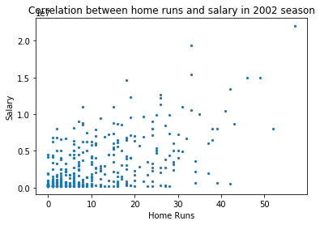

```python
%pylab inline
plt.scatter(HR_2002,salary_2002,s=5)
plt.xlabel('Home Runs')
plt.ylabel('Salary')
plt.title('Correlation between home runs and salary in 2002 season')
plt.show()
```

```python
no_pitcher_2005_df[no_pitcher_2005_df['playerID'] == 'rodrial01']
```

|  | playerID | yearID | teamID | G | AB | R | H | HR | RBI | POS | lgID | salary | BA |
| --- | --- | --- | --- | --- | --- | --- | --- | --- | --- | --- | --- | --- | --- |
| 805 | rodrial01 | 2005 | NYA | 162 | 605 | 124 | 194 | 48 | 130.0 | 3B | AL | 26000000 | 0.320661 |

```python
no_pitcher_2005_df['BA'].describe()
```

```
count    413.000000
mean       0.256736
std        0.047502
min        0.000000
25%        0.240918
50%        0.263323
75%        0.284091
max        0.500000
Name: BA, dtype: float64
```

```python
sample_batting_BA_2005 = standardize_column(no_pitcher_2005_df['BA'])
#standardize column in smaller sample population.


sample_batting_BA_2005[805]
```

```
1.345721607824405
```

Here, I see that batting average value in the 2005 season for Alex Rodriguez is also above the mean. He is 1.3457 standard deviations above the average. The distribution for batting average in the 2005 season seems to follow a normal distribution.

```python
HR_2005 = no_pitcher_2005_df['HR']
salary_2005 = no_pitcher_2005_df['salary']
BA_2005 = no_pitcher_2005_df['BA']
print("correlation between home runs and salary in 2005:" + str(correlation(HR_2005,salary_2005)))

print("correlation between batting average and salary in 2005:" + str(correlation(BA_2005,salary_2005)))
```

```
correlation between home runs and salary in 2005:0.45611352159330193
correlation between batting average and salary in 2005:0.21009487492782403
```

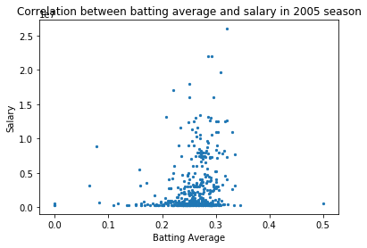

```python
%pylab inline
plt.scatter(BA_2005,salary_2005,s=5)
plt.xlabel('Batting Average')
plt.ylabel('Salary')
plt.title('Correlation between batting average and salary in 2005 season')
plt.show()
```

## Conclusions

There are obvious limitations to this analysis that I should point out. For starters, most of my project involved bivariate analysis. I ignored a lot of other factors that pertain to a game of baseball, most notably in this analysis I focused only on one side of the game: offense. There is a whole other aspect of baseball that players get paid for (pitching/defense) that I did not include in this analysis. Also, just within offense itself, there are many layers that are interlaced and effect one another; attempting to focus on one aspect is not the see all end all. Batting average and home runs itself is related to one another. In fact, I could have calculated a correlation matrix from a specific year to test how much each baseball metric affected one another.

I also decided not to analyze any other variables and narrowed it down to just home runs and batting average. If i hadn't narrowed down my variables of choice, I would still be writing a script to analyze all aspects of baseball to this day. That type of analysis is more suited to higher degrees of data analysis such as machine learning.

This analysis did allow for me the opportunity to play around with datasets through my use of python's built-in libraries (pandas, numpy) and create visualizations as well. I used a few makeshift logical statements to get a better understanding of the dataset. All in all, this was a very fun project and I look forward to making improvements as I continue to delve deeper into data analytics.

```python
from subprocess import call
call(['python', '-m', 'nbconvert', 'Investigate_a_Dataset.ipynb'])
```

```
1
```